# 이산형 확률분포

### 확률분포 히트맵 생성

### `ax.pcolor(data)`

### `ax.invert_yaxis()` : y축 기준 역전

### `ax.xaxis.tick_top()` : x축의 눈금을 위쪽에 표시

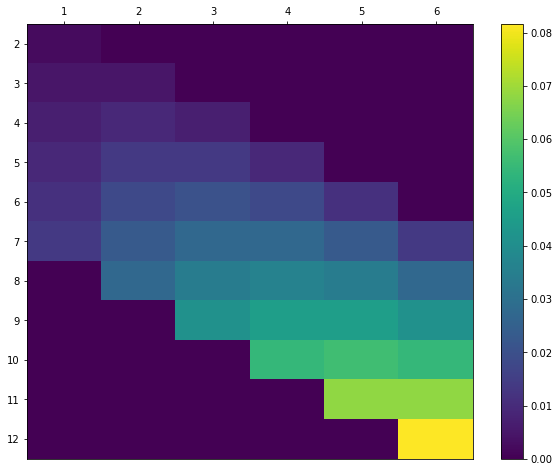

```python
fig = plt.figure(figsize = (10, 8))
ax = fig.add_subplot(111)

c = ax.pcolor(prob)

ax.set_xticks(np.arange(prob.shape[1]) + 0.5, minor = False)
ax.set_yticks(np.arange(prob.shape[0]) + 0.5, minor = False)
ax.set_xticklabels(np.arange(1, 7), minor = False)
ax.set_yticklabels(np.arange(2, 13), minor = False)

# y축을 내림차순의 숫자가 되게 하여, 위 아래를 역전
ax.invert_yaxis()

# x축의 눈금을 그래프 위쪽에 표시
ax.xaxis.tick_top()

# 색 막대 생성
fig.colorbar(c, ax = ax)

plt.show()
```

- 모든 확률이 0이상인지, 확률의 총합이 1인지 확인

```python
np.all(prob >= 0)
```

```
True
```

```python
np.sum(prob)
```

```
1.000
```

### 주변확률분포 : 결합확률함수 $f_{XY}$에서 확률변수 하나의 영향을 제거

- 확률변수 (X, Y)는 결합확률분포에 의해 동시에 정의됨
- **개별 확률변수의 변동을 파악할 시 (확률변수 X만의 변동) => 확률변수 X의 확률함수를 알고 싶은 상황**

#### **확률변수 X의 확률함수 $f_X (x)는 결합확률함수 f_{XY}$에서 Y가 취할 수 있는 값 모두를 대입한 다음 모두 더함**

### $f_X (x) = \sum_k f_{XY}(x, y_k)$

#### X와 Y의 주변확률함수

```python
def f_X(x):
    return np.sum([f_XY(x, y_k) for y_k in y_set])
```

```python
def f_Y(y):
    return np.sum([f_XY(x_k, y) for x_k in x_set])
```

```python
X = [x_set, f_X]
Y = [y_set, f_Y]
X, Y
```

```
([array([ 2,  3,  4,  5,  6,  7,  8,  9, 10, 11, 12]),
  <function __main__.f_X(x)>],
 [array([1, 2, 3, 4, 5, 6]), <function __main__.f_Y(y)>])
```

```python
prob_x = np.array([f_X(x_k) for x_k in x_set])
prob_y = np.array([f_Y(y_k) for y_k in y_set])
prob_x, prob_y
```

```
(array([0.002, 0.009, 0.023, 0.045, 0.079, 0.127, 0.159, 0.172, 0.166,
        0.136, 0.082]),
 array([0.048, 0.095, 0.143, 0.19 , 0.238, 0.286]))
```

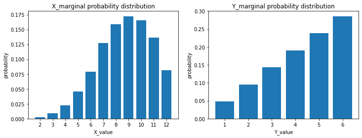

```python
fig = plt.figure(figsize = (12, 4))
ax1 = fig.add_subplot(121)
ax2 = fig.add_subplot(122)

ax1.bar(x_set, prob_x)

ax1.set_title('X_marginal probability distribution')
ax1.set_xlabel('X_value')
ax1.set_ylabel('probability')
ax1.set_xticks(x_set)

ax2.bar(y_set, prob_y)
ax2.set_title('Y_marginal probability distribution')
ax2.set_xlabel('Y_value')
ax2.set_ylabel('probability')

plt.show()
```

### 2차원 이산형 확률분포의 지표

### 기댓값 (평균)

### $\mu_X = E(X) = \sum_i \sum_j x_i f_{XY}(x_i, y_j)$

```python
np.sum([x_i * f_XY(x_i, y_j) for x_i in x_set for y_j in y_set])
```

```
8.667
```

### $E(g(X, Y) = \sum_i \sum_j g(x_i, y_j) f_{XY}(x_i, y_j)$

```python
XY
```

```
[array([ 2,  3,  4,  5,  6,  7,  8,  9, 10, 11, 12]),
 array([1, 2, 3, 4, 5, 6]),
 <function __main__.f_XY(x, y)>]
```

```python
def E(XY, g):
    x_set, y_set, f_XY = XY
    return np.sum([g(x_i, y_j) * f_XY(x_i, y_j)
                   for x_i in x_set for y_j in y_set])
```

#### X와 Y의 기댓값

```python
mean_X = E(XY, lambda x, y : x)
mean_X
```

```
8.667
```

```python
mean_Y = E(XY, lambda x, y : y)
mean_Y
```

```
4.333
```

### 기댓값의 선형성

### $E(aX + bY) = aE(X) + bE(Y)$

```python
a, b = 2, 3
```

```python
E(XY, lambda x, y : a * x + b * y)
```

```
30.333
```

```python
a * mean_X + b * mean_Y
```

```
30.333
```

### 분산

### $\sigma^2_X = V(X) = \sum_i \sum_j (x_i - \mu_X)^2 f_{XY}(x_i, y_j)$

```python
np.sum([(x_i - mean_X)**2 * f_XY(x_i, y_j)
       for x_i in x_set for y_j in y_set])
```

```
4.444
```

### $V(g(X, Y)) = \sum_i \sum_j(g(x_i, y_j) - E(g(X, Y)))^2 f_{XY}(x_i, y_j)$

```python
def V(XY, g):
    x_set, y_set, f_XY = XY
    mean = E(XY, g)
    return np.sum([(g(x_i, y_j)-mean)**2 * f_XY(x_i, y_j)
                   for x_i in x_set for y_j in y_set])
```

### X와 Y의 분산

```python
var_X = V(XY, g = lambda x, y: x)
var_X
```

```
4.444
```

```python
var_Y = V(XY, g = lambda x, y: y)
var_Y
```

```
2.222
```

### 공분산

- **2개의 확률변수 X, Y 사이의 상관관계 파악**

### $\sigma_{XY} = Cov(X, Y) = \sum_i \sum_j (x_i - \mu_X)(y_j - \mu_Y) f_{XY}(x_i, y_j)$

```python
def Cov(XY):
    x_set, y_set, f_XY = XY
    mean_X = E(XY, lambda x, y: x)
    mean_Y = E(XY, lambda x, y: y)
    return np.sum([(x_i - mean_X) * (y_j - mean_Y) * f_XY(x_i, y_j)
                    for x_i in x_set for y_j in y_set])
```

```python
cov_xy = Cov(XY)
cov_xy
```

```
2.222
```

### 분산과 공분산의 관계

### $V(aX + bY) = a^2\;V(X) + b^2\;V(Y) + 2ab \; Cov(X, y)$

#### $V(2X + 3Y) = 4(V(X) + 9V(Y) + 12 Cov(X, Y)$

```python
V(XY, lambda x, y : a * x + b * y)
```

```
64.444
```

```python
a**2 * var_X + (b**2) * var_Y + (2 * a * b) * cov_xy
```

```
64.444
```

### 상관계수

### $\rho_{XY} = \rho(X, Y) = {{\sigma_{XY}} \over {\sigma_X \sigma_Y}}$

```python
cov_xy / np.sqrt(var_X * var_Y)
```

```
0.707
```